# Assignment2_G06

Load the dataset

```python
import pandas as pd
df = pd.read_csv("creditcard.csv")
```

Show first 6 data points using head().

```python
df.head(6)
```

|  | Time | V1 | V2 | V3 | V4 | V5 | V6 | V7 | V8 | V9 | ... | V21 | V22 | V23 | V24 | V25 | V26 | V27 | V28 | Amount | Class |
| --- | --- | --- | --- | --- | --- | --- | --- | --- | --- | --- | --- | --- | --- | --- | --- | --- | --- | --- | --- | --- | --- |
| 0 | 0.0 | -1.359807 | -0.072781 | 2.536347 | 1.378155 | -0.338321 | 0.462388 | 0.239599 | 0.098698 | 0.363787 | ... | -0.018307 | 0.277838 | -0.110474 | 0.066928 | 0.128539 | -0.189115 | 0.133558 | -0.021053 | 149.62 | 0 |
| 1 | 0.0 | 1.191857 | 0.266151 | 0.166480 | 0.448154 | 0.060018 | -0.082361 | -0.078803 | 0.085102 | -0.255425 | ... | -0.225775 | -0.638672 | 0.101288 | -0.339846 | 0.167170 | 0.125895 | -0.008983 | 0.014724 | 2.69 | 0 |
| 2 | 1.0 | -1.358354 | -1.340163 | 1.773209 | 0.379780 | -0.503198 | 1.800499 | 0.791461 | 0.247676 | -1.514654 | ... | 0.247998 | 0.771679 | 0.909412 | -0.689281 | -0.327642 | -0.139097 | -0.055353 | -0.059752 | 378.66 | 0 |
| 3 | 1.0 | -0.966272 | -0.185226 | 1.792993 | -0.863291 | -0.010309 | 1.247203 | 0.237609 | 0.377436 | -1.387024 | ... | -0.108300 | 0.005274 | -0.190321 | -1.175575 | 0.647376 | -0.221929 | 0.062723 | 0.061458 | 123.50 | 0 |
| 4 | 2.0 | -1.158233 | 0.877737 | 1.548718 | 0.403034 | -0.407193 | 0.095921 | 0.592941 | -0.270533 | 0.817739 | ... | -0.009431 | 0.798278 | -0.137458 | 0.141267 | -0.206010 | 0.502292 | 0.219422 | 0.215153 | 69.99 | 0 |
| 5 | 2.0 | -0.425966 | 0.960523 | 1.141109 | -0.168252 | 0.420987 | -0.029728 | 0.476201 | 0.260314 | -0.568671 | ... | -0.208254 | -0.559825 | -0.026398 | -0.371427 | -0.232794 | 0.105915 | 0.253844 | 0.081080 | 3.67 | 0 |

6 rows × 31 columns

Describe pandas Dataframe by using describe.

```python
df.describe()
```

|  | Time | V1 | V2 | V3 | V4 | V5 | V6 | V7 | V8 | V9 | ... | V21 | V22 | V23 | V24 | V25 | V26 | V27 | V28 | Amount | Class |
| --- | --- | --- | --- | --- | --- | --- | --- | --- | --- | --- | --- | --- | --- | --- | --- | --- | --- | --- | --- | --- | --- |
| count | 284807.000000 | 2.848070e+05 | 2.848070e+05 | 2.848070e+05 | 2.848070e+05 | 2.848070e+05 | 2.848070e+05 | 2.848070e+05 | 2.848070e+05 | 2.848070e+05 | ... | 2.848070e+05 | 2.848070e+05 | 2.848070e+05 | 2.848070e+05 | 2.848070e+05 | 2.848070e+05 | 2.848070e+05 | 2.848070e+05 | 284807.000000 | 284807.000000 |
| mean | 94813.859575 | 1.168375e-15 | 3.416908e-16 | -1.379537e-15 | 2.074095e-15 | 9.604066e-16 | 1.487313e-15 | -5.556467e-16 | 1.213481e-16 | -2.406331e-15 | ... | 1.654067e-16 | -3.568593e-16 | 2.578648e-16 | 4.473266e-15 | 5.340915e-16 | 1.683437e-15 | -3.660091e-16 | -1.227390e-16 | 88.349619 | 0.001727 |
| std | 47488.145955 | 1.958696e+00 | 1.651309e+00 | 1.516255e+00 | 1.415869e+00 | 1.380247e+00 | 1.332271e+00 | 1.237094e+00 | 1.194353e+00 | 1.098632e+00 | ... | 7.345240e-01 | 7.257016e-01 | 6.244603e-01 | 6.056471e-01 | 5.212781e-01 | 4.822270e-01 | 4.036325e-01 | 3.300833e-01 | 250.120109 | 0.041527 |
| min | 0.000000 | -5.640751e+01 | -7.271573e+01 | -4.832559e+01 | -5.683171e+00 | -1.137433e+02 | -2.616051e+01 | -4.355724e+01 | -7.321672e+01 | -1.343407e+01 | ... | -3.483038e+01 | -1.093314e+01 | -4.480774e+01 | -2.836627e+00 | -1.029540e+01 | -2.604551e+00 | -2.256568e+01 | -1.543008e+01 | 0.000000 | 0.000000 |
| 25% | 54201.500000 | -9.203734e-01 | -5.985499e-01 | -8.903648e-01 | -8.486401e-01 | -6.915971e-01 | -7.682956e-01 | -5.540759e-01 | -2.086297e-01 | -6.430976e-01 | ... | -2.283949e-01 | -5.423504e-01 | -1.618463e-01 | -3.545861e-01 | -3.171451e-01 | -3.269839e-01 | -7.083953e-02 | -5.295979e-02 | 5.600000 | 0.000000 |
| 50% | 84692.000000 | 1.810880e-02 | 6.548556e-02 | 1.798463e-01 | -1.984653e-02 | -5.433583e-02 | -2.741871e-01 | 4.010308e-02 | 2.235804e-02 | -5.142873e-02 | ... | -2.945017e-02 | 6.781943e-03 | -1.119293e-02 | 4.097606e-02 | 1.659350e-02 | -5.213911e-02 | 1.342146e-03 | 1.124383e-02 | 22.000000 | 0.000000 |
| 75% | 139320.500000 | 1.315642e+00 | 8.037239e-01 | 1.027196e+00 | 7.433413e-01 | 6.119264e-01 | 3.985649e-01 | 5.704361e-01 | 3.273459e-01 | 5.971390e-01 | ... | 1.863772e-01 | 5.285536e-01 | 1.476421e-01 | 4.395266e-01 | 3.507156e-01 | 2.409522e-01 | 9.104512e-02 | 7.827995e-02 | 77.165000 | 0.000000 |
| max | 172792.000000 | 2.454930e+00 | 2.205773e+01 | 9.382558e+00 | 1.687534e+01 | 3.480167e+01 | 7.330163e+01 | 1.205895e+02 | 2.000721e+01 | 1.559499e+01 | ... | 2.720284e+01 | 1.050309e+01 | 2.252841e+01 | 4.584549e+00 | 7.519589e+00 | 3.517346e+00 | 3.161220e+01 | 3.384781e+01 | 25691.160000 | 1.000000 |

8 rows × 31 columns

Show correlation heat plot of the entire dataset using matplotlib and sns, choose any color pallet (except blue) you like (experiment).

```python
import matplotlib.pyplot as plt
import seaborn as sns
```

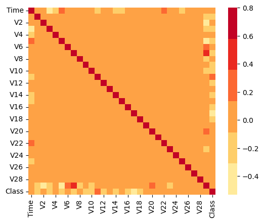

```python
df_corr = df.corr()

exp_palette = sns.color_palette("YlOrRd")

# code referred from supporting code
sns.heatmap(df_corr,
            cmap = exp_palette,
            vmax=.8,
            square=True,
            annot=False,
)

plt.show()
```

Show the Scatterplot matrix for the dataframe (avoid matplotlib and sns for this assignment). You can use Scatterplot Matrix Plotly. Use the code for the second image that shows different colors for classes. In this case, you will get two colors since we have two classes. Also, experiment with visual aspects of the image (not a lot, but an excellent visual will always leave a better impression. you can change color, thickness, font, font size, font color, etc.). No need to explain the plots but do save them in a pdf/svg/png with either static export function or html export function from plotly Interactive HTML Export Plotly.

```python
import random
random.seed(4217)
```

```python
df['Class'] = df.Class.astype('category')
```

```python
dfX = df.drop("Class", axis=1)
```

```python
import numpy as np
dfX = dfX[np.random.choice(dfX.columns.tolist(), size=10, replace=False)]
```

```python
dfXy = pd.concat([dfX, df['Class']], axis=1)
```

```python
# code referred from supporting code
import plotly.express as px

fig = px.scatter_matrix(dfXy, color='Class')
fig.update_layout(
    title='Credit Card Transaction Dataset',
    dragmode='select',
    width=600,
    height=600,
    hovermode='closest',
)
fig.write_html("plotly_scatterplot.html")
```

Split the dataset into the Training set and Test set. Choose your preferred split and justify the rationale.

```python
X = df.loc[:, df.columns != 'Class'].to_numpy()
y = df.iloc[:,-1:].to_numpy()
```

```python
from sklearn.model_selection import train_test_split

X_train, X_test, y_train, y_test = train_test_split(X, y, test_size=0.30, random_state=0)
```

```python
X_train.shape
```

```
(199364, 30)
```

```python
X_test.shape
```

```
(85443, 30)
```

The split method I use is the build-in function from sklearn called train-test-split, and I choose the split to be 70-30 since there many data points, so 70% train set is sufficient to train

Perform classification routine by using LogisticRegression(), KNeighborsClassifier(), DecisionTreeClassifier(), SVC(), GaussianNB(), RandomForestClassifier(), BaggingClassifier(), GradientBoostingClassifier(), XGboostclassifier. Output the accuracy box plot as we have seen in the class (make sure to change regressmod df to classmod. And use an appropriate metric for classification evaluation, for example, accuracy, precision,recall etc). Remember to use the object oriented approach and develop a function (def...), this will be very helpful for the next assignment.

```python
from sklearn.linear_model import LogisticRegression
from sklearn.neighbors import KNeighborsClassifier
from sklearn.tree import DecisionTreeClassifier
from sklearn.svm import SVC
from sklearn.naive_bayes import GaussianNB
from sklearn.ensemble import RandomForestClassifier, BaggingClassifier, GradientBoostingClassifier
import xgboost as xgb
```

```python
# code referred from supporting code

def base_models():
  models = dict()
  models['LogisticRegression'] = LogisticRegression()
  models["KNeighborsClassifier"] = KNeighborsClassifier()
  models["DecisionTreeClassifier"] = DecisionTreeClassifier()
  models["SVC"] = SVC()
  models["GaussianNB"] = GaussianNB()
  models["RandomForestClassifier"] = RandomForestClassifier()
  models["BaggingClassifier"] = BaggingClassifier()
  models["GradientBoostingClassifier"] = GradientBoostingClassifier()
  models["XGboostclassifier"] = xgb.XGBClassifier()
  return models
```

```python
# code referred from supporting code
from sklearn.model_selection import cross_val_score, RepeatedKFold

def eval_models(model):
  cv = RepeatedKFold(n_splits=10, n_repeats=3, random_state=1)
  scores = cross_val_score(model, X_train, y_train, cv=cv, n_jobs=-1,
                            error_score='raise')
  return scores
```

```python
# code referred from supporting code
models = base_models()
# evaluate the models and store results
results, names = list(), list()

for name, model in models.items():
  scores = eval_models(model)
  results.append(scores)
  names.append(name)
  print('>%s %.3f (%.3f)' % (name, scores.mean(), scores.std()))
```

```
>LogisticRegression 0.999 (0.000)
>KNeighborsClassifier 0.998 (0.000)
>DecisionTreeClassifier 0.999 (0.000)
>SVC 0.998 (0.000)
>GaussianNB 0.993 (0.001)
>RandomForestClassifier 1.000 (0.000)
>BaggingClassifier 0.999 (0.000)
>GradientBoostingClassifier 0.999 (0.000)
>XGboostclassifier 1.000 (0.000)
```

```python
# code referred from supporting codes

classmod = pd.DataFrame(np.transpose(results), columns = ["LogisticRegression","KNeighborsClassifier","DecisionTreeClassifier","SVC","GaussianNB","RandomForestClassifier","BaggingClassifier", "GradientBoostingClassifier", "XGboostclassifier"])
classmod = pd.melt(classmod.reset_index(), id_vars='index',value_vars=["LogisticRegression","KNeighborsClassifier","DecisionTreeClassifier","SVC","GaussianNB","RandomForestClassifier","BaggingClassifier", "GradientBoostingClassifier", "XGboostclassifier"])
```

```python
# code referred from supporting codes
from plotly.subplots import make_subplots
import plotly.graph_objs as go

fig = px.box(classmod, x="variable", y="value",color="variable",points='all',
labels={"variable": "Machine Learning Model",
        "value": "Accuracy Scores"
        },title="Model Performance")
fig.write_html("plotly_boxplot.html")
```

```python
# code referred from supporting code
from sklearn.ensemble import StackingClassifier # choose stackingclassifier for level0

def get_stacking():
	# define the base models
  level0 = list()
  level0.append(('RandomForestClassifier', RandomForestClassifier())) # either random forest and XGBoost classifier has accuarcy of 1, here I choose random forest

	# define meta learner model
  level1 = LogisticRegression()
	# define the stacking ensemble
  model = StackingClassifier(estimators=level0, final_estimator=level1, cv=5)
  return model
```

```python
# code referred from supporting code
def base_stack_models():
  models = dict()
  models["RandomForestClassifier"] = RandomForestClassifier()
  models["LogisticRegression"] = LogisticRegression()
  models["Stacked Model"] = get_stacking()
  return models
```

```python
# code referred from supporting code

def eval_stack_models(model):
  cv = RepeatedKFold(n_splits=10, n_repeats=3, random_state=1)
  scores = cross_val_score(model, X_train, y_train, cv=cv, n_jobs=-1,
                            error_score='raise')
  return scores
```

```python
# code referred from supporting codes
stack_models = base_stack_models()
# evaluate the models and store results
stack_results, stack_names = list(), list()

for name, model in stack_models.items():
  scores = eval_stack_models(model)
  stack_results.append(scores)
  stack_names.append(name)
  print('>%s %.3f (%.3f)' % (name, scores.mean(), scores.std()))
```

The above cell taks extremely long time to execute, causing the google colab disconnection, so I just stop it

Export the Pickle model and import it back. Use the imported model to predic the y_test from x_test and report the confusion metrix

```python
# code referred from supporting code
import pickle

level0 = list()
level0.append(('KNeighborsClassifier', KNeighborsClassifier())) # use knn bc it takes shorter time

level1 = LogisticRegression()
model = StackingClassifier(estimators=level0, final_estimator=level1, cv=5)
model.fit(X_train, y_train)
```

```
StackingClassifier(cv=5,
                   estimators=[('KNeighborsClassifier',
                                KNeighborsClassifier())],
                   final_estimator=LogisticRegression())
```

```python
# code referred from supporting code
pkl_filename = "AssignmentPickle.pkl"
with open(pkl_filename, 'wb') as file:
    pickle.dump(model, file)
```

```python
# code referred from supporting code
with open(pkl_filename, 'rb') as file:
    pickle_model = pickle.load(file)
```

```python
# code referred from supporting code

score = pickle_model.score(X_test, y_test)
print("Test score: {0:.2f} %".format(100 * score))
Y_predict = pickle_model.predict(X_test)
```

```
Test score: 99.83 %
```

```python
import seaborn as sns
```

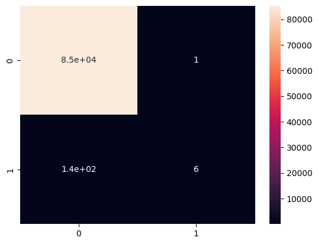

```python
from sklearn.metrics import confusion_matrix

cm = confusion_matrix(y_test, Y_predict)
sns.heatmap(cm, annot=True)
```

Show both text and visual confusion Matrices using scikit learn and matplotlib and explain what the graph tells you and what you did.

```
[[85295     1]
 [  141     6]]
```

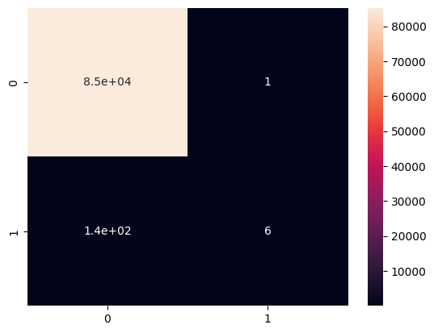

```python
print(cm)
sns.heatmap(cm, annot=True)
```

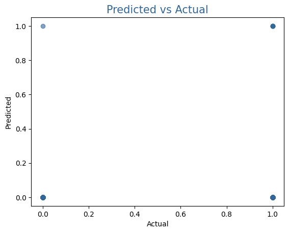

```python
# code referred from supporting code
import matplotlib.pyplot as plt

predictions = pd.DataFrame(Y_predict, columns=['predictions'])
predictions['actual'] = y_test
plt.scatter(x = y_test, y = Y_predict, color='#336699',alpha=0.6)
plt.xlabel('Actual')
plt.ylabel('Predicted')
plt.title('Predicted vs Actual', fontsize=15, color='#336699',loc='center')
```

```python
!jupyter nbconvert --to html Assignment2_G06.ipynb
```

[output not shown]

[output cut: 133 more lines]

[output not shown]